# SAT_Practice_0318

Question ID: 06_304

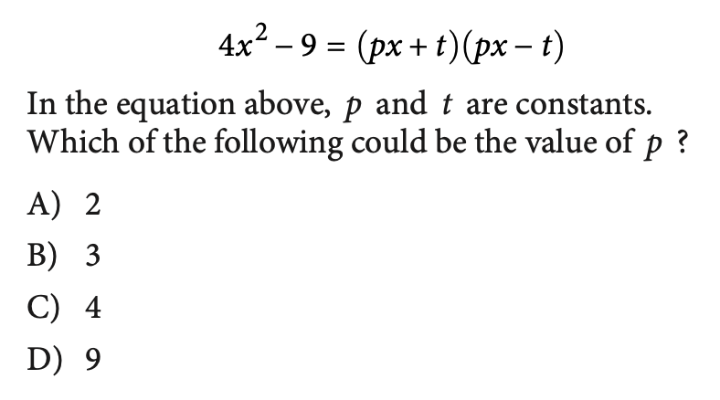

ABCD

The correct answer is A

Question ID: 04_315

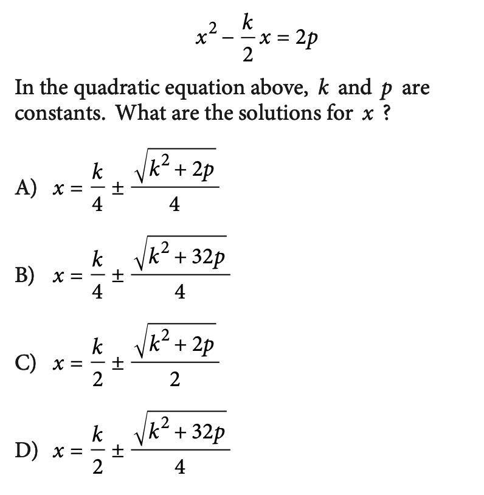

ABCD

The correct answer is B

Question ID: 09_402

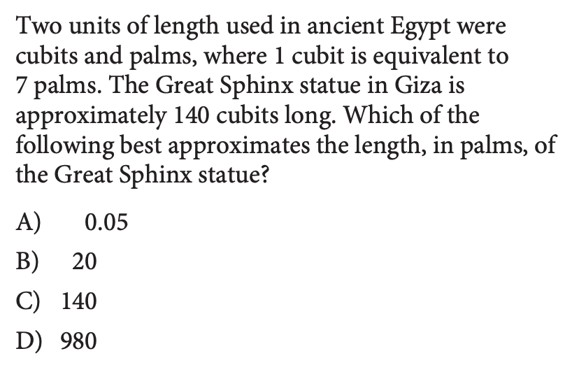

ABCD

The correct answer is D

Question ID: 03_306

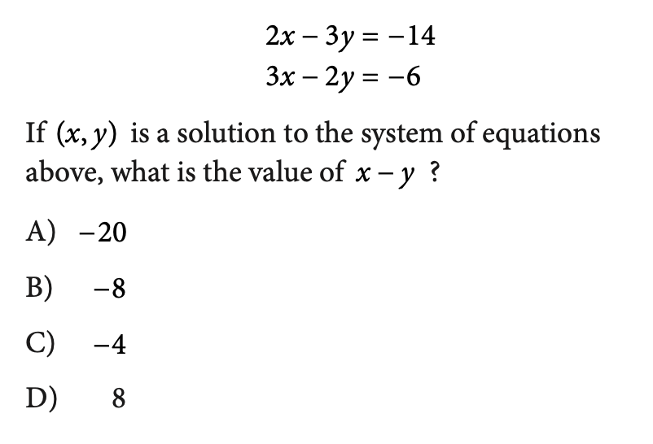

ABCD

The correct answer is C

Question ID: 04_408

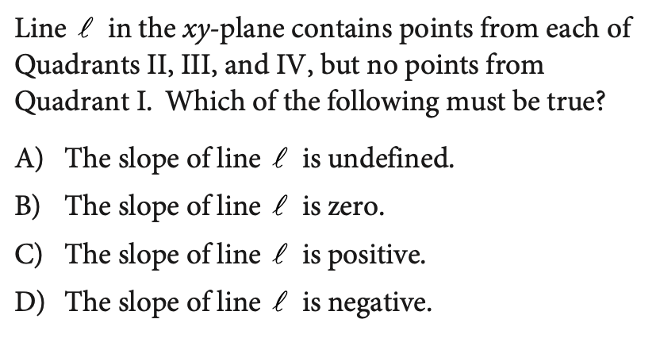

ABCD

The correct answer is D

Question ID: 10_318

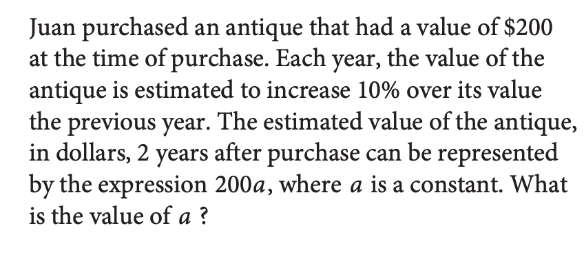

The correct answer is 1.21.

Question ID: 12_112

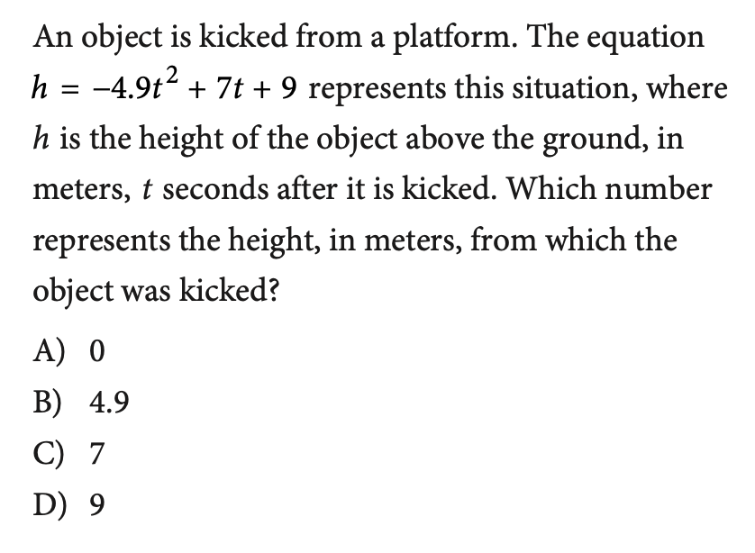

ABCD

The correct answer is D

Question ID: 14_215

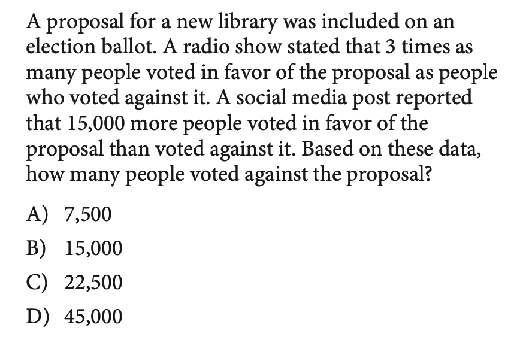

ABCD

The correct answer is A

Question ID: 10_306

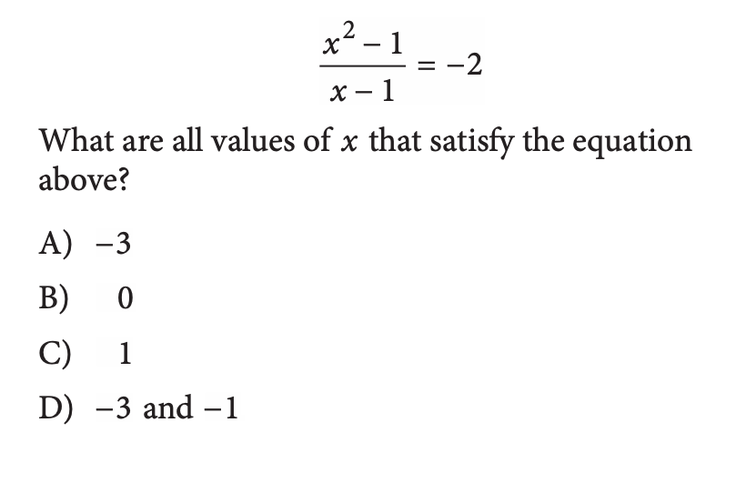

ABCD

The correct answer is A

Question ID: 08_422

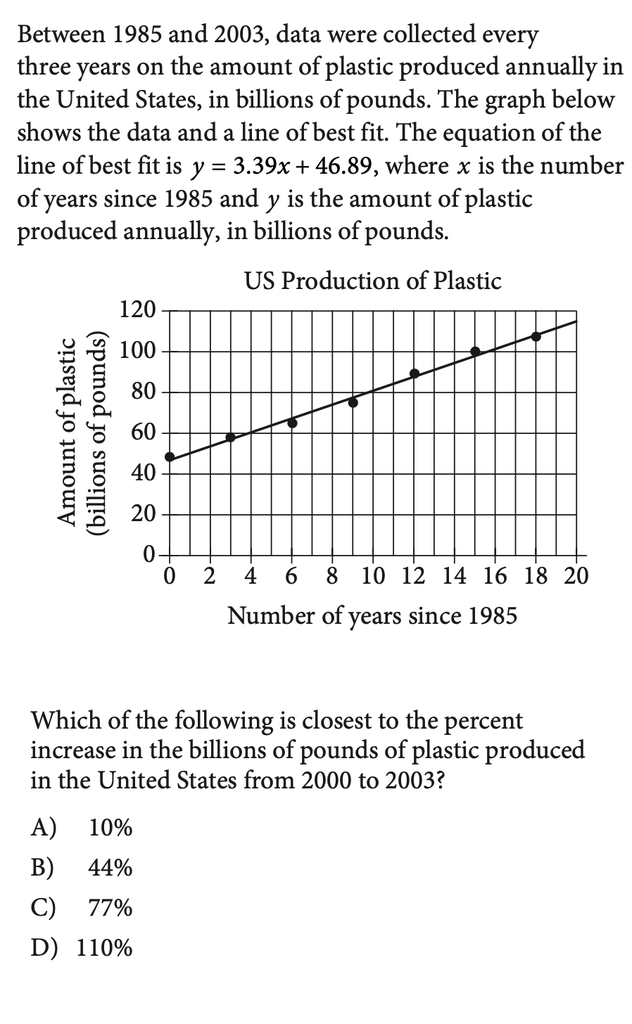

ABCD

The correct answer is A

Question ID: 12_203

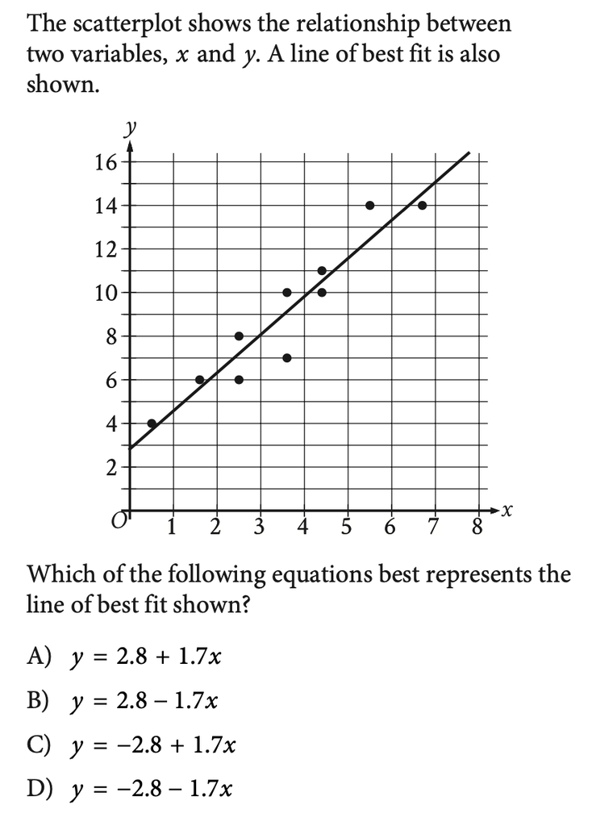

ABCD

The correct answer is A

Question ID: 05_304

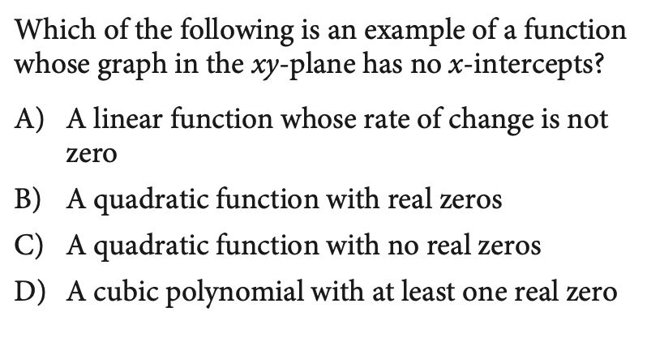

ABCD

The correct answer is C

Question ID: 13_206

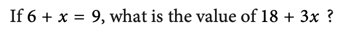

The correct answer is 27.

Question ID: 05_320

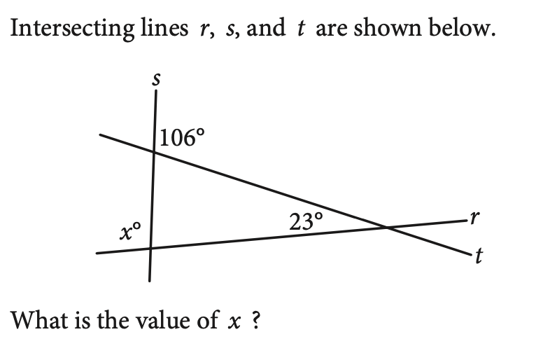

The correct answer is 97.

Question ID: 04_431

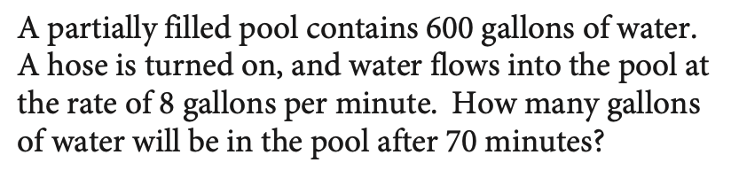

The correct answer is 1160.

Question ID: 06_408

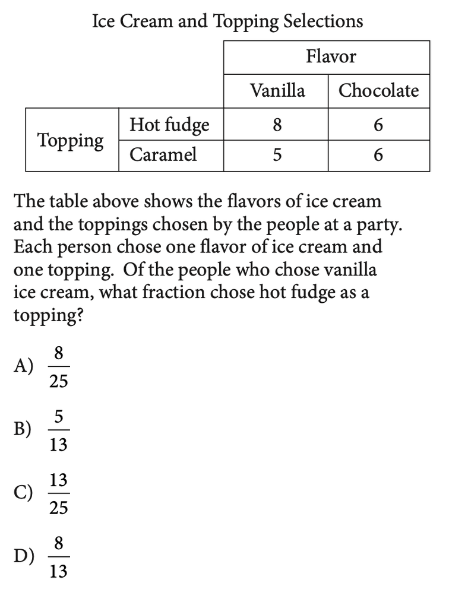

ABCD

The correct answer is D

Question ID: 02_432

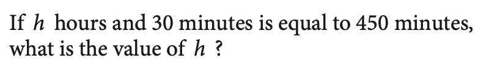

The correct answer is 7.

Question ID: 12_219

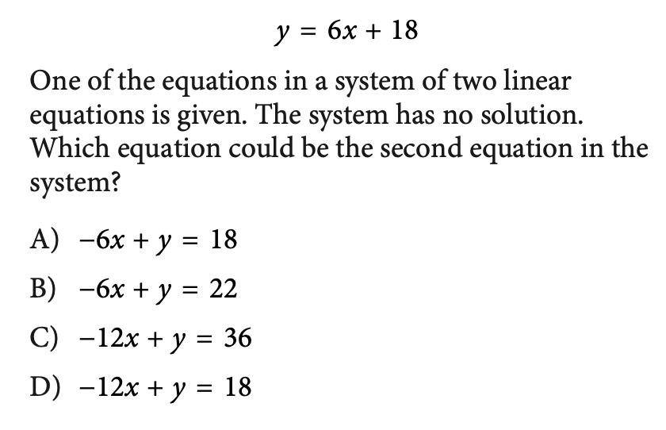

ABCD

The correct answer is B

Question ID: 07_437

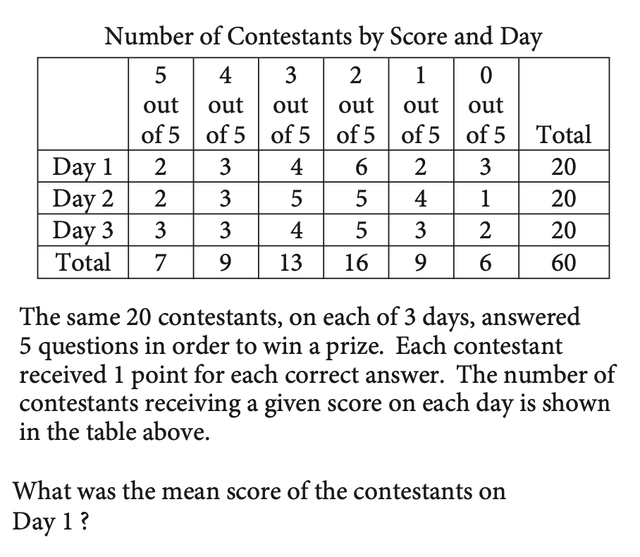

The correct answer is 2.4.

Question ID: 10_319

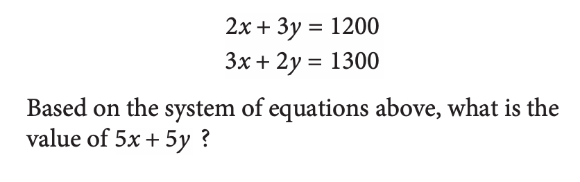

The correct answer is 2500.

Question ID: 04_415

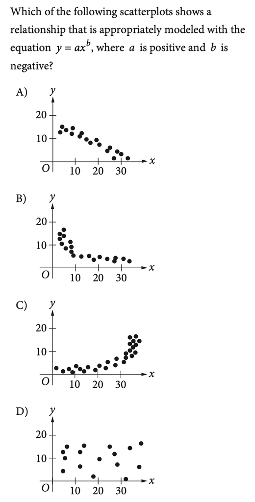

ABCD

The correct answer is B

Question ID: 11_115

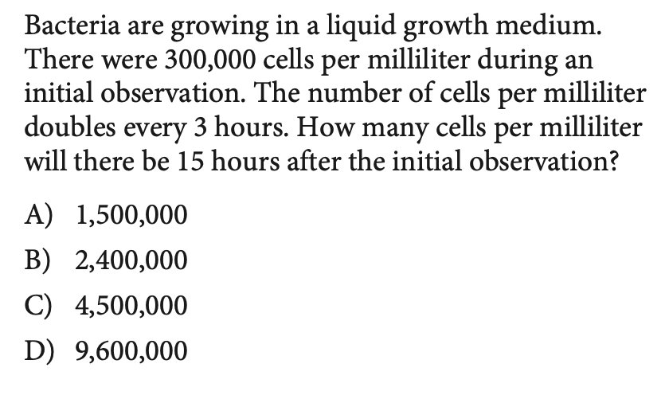

ABCD

The correct answer is D